# MLE Simulation and Censored Data Analysis

Kyle P Messier, PhD

# Maximum Likelihood Estimation (MLE) and Censored Data

In this brief tutorial, we will explore how to estimate parameters for a normal distribution given observed and censored data. Censored data is encountered in many fields, including environmental science, where we often have data below the method detection limit (MDL). That is generally a good thing for public health as it means the concentration of the contaminant is below a level that we can detect; however, it is a challenge for statisticians and data analysts as more sophisticated methods are needed. Here, we show how to produce these estimates using base R code and functions.

# Simulate ~ N(0,1) data

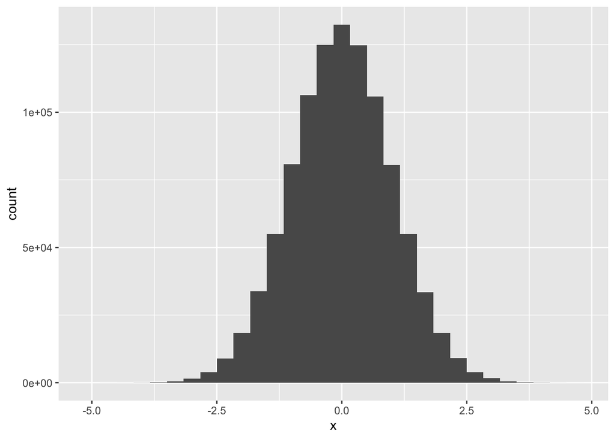

```r
x <- rnorm(10^6)

ggplot(data.frame(x = x), aes(x = x)) + geom_histogram()
```

# Create a negative log-likelihood function for normal data

The negative Log-Likelihood function for a normal distribution is the negative of the sum of the log of the density function of the normal distribution.

```r
 rMLE <- function(params, y){

   mu = params[1]
   sigma = params[2]

   return(-1 * sum(dnorm(y, mean = mu, sd = sigma, log = TRUE)))

 }
```

# MLE Examples

## 100 percent observed MLE

We use starting values kind of far away from true values to make sure the optimization converges to the right values for this easy case.

```r
 mle0 <- optim(par = c(2,3), rMLE, y = x)
 results <- mle0$par
 print(results)
```

```
## [1] -0.0005672447  1.0017681739
```

Try with a different mean and standard deviation. Also, we start with starting values quite different to make sure the optimization converges to the right values for this easy case

```r
 x3 <- rnorm(10^6, mean = 3, sd = 6)

 mle3 <- optim(par = c(0,1), rMLE, y = x3)

 results3 <- mle3$par
 print(results3)
```

```
## [1] 3.000372 6.003552
```

## Censored MLE

```r
 cMLE <- function(params, y.obs, y.cens = NULL){

   mu = params[1]
   sigma = params[2]


    obs_ll <- sum(dnorm(y.obs, mean = mu, sd = sigma, log = TRUE))
    cens_ll <- sum(pnorm(y.cens, mean = mu, sd = sigma, log.p = TRUE, lower.tail = TRUE))
    nll <- -1 * (obs_ll + cens_ll)

    return(nll)

 }
```

### Check that the censored ML is working.

We will do a loop by censoring more and more data below the MDL. The MLE estimates should deviate more and more from the observed mean and standard deviation as we censor more data.

```r
MDL <- -1.5

p <- seq(0.1, 1, by = 0.1)

results <- list()


for (i in 1:length(p)){

  # random sample of p percent of the data
  idx <- c(1:length(x)) %in% sample.int(length(x), length(x) * p[i])

  cens_data <- rep(MDL, length(x) * (1-p[i]))
  obs_data <- x[idx]

  mle <- optim(par = c(0,1), cMLE, y.obs = obs_data, y.cens = cens_data)

  results[[i]] <- mle$par

  print(paste("mu = ",results[[i]][1], "sd = ", results[[i]][2], "censored percentage = ", (100-p[i]*100)))

}
```

```
## [1] "mu =  -5.31750423155223 sd =  2.99598992330207 censored percentage =  90"
## [1] "mu =  -3.59224139144862 sd =  2.52480236527843 censored percentage =  80"
## [1] "mu =  -2.62398668350696 sd =  2.22248204350957 censored percentage =  70"
## [1] "mu =  -1.95598827735521 sd =  1.9839012945653 censored percentage =  60"
## [1] "mu =  -1.45390497742119 sd =  1.78424633393534 censored percentage =  50"
## [1] "mu =  -1.0528981110896 sd =  1.60641361688904 censored percentage =  40"
## [1] "mu =  -0.723229678711459 sd =  1.44538054877329 censored percentage =  30"
## [1] "mu =  -0.446381669961556 sd =  1.29352580626401 censored percentage =  20"
## [1] "mu =  -0.208009273069911 sd =  1.14639648496523 censored percentage =  10"
## [1] "mu =  -0.000572354732867098 sd =  1.0015501772592 censored percentage =  0"
```

The results seem to make sense; As the censoring decrease the MLE estimates get closer to the true values. Additionally, as the censoring increases, the mean moves farther towards -Inf, away from the MDL.

# MLE Trick for Strictly Positive Parameters

We often have to estimate parameters that are strictly positive. For example, the mean concentration on the normal scale should be non-negative or a variance parameter (e.g. Kriging variance/sill).

One trick is to estimate the log of the parameter. Our estimate is then $exp(x)$. This way, the parameter is always positive. We could do constrained optimization, but the algorithms for unconstrained optimization are more efficient and more robust.

## MLE for observed data and log parameters

```r
 rMLE_log <- function(params, y){

   mu = exp(params[1])
   sigma = exp(params[2])

   return(-1 * sum(dnorm(y, mean = mu, sd = sigma, log = TRUE)))

 }

# Simulate strictly positive log-normal data
z <- rlnorm(10^3, meanlog = 3, sdlog = 1)

mle_log <- optim(par = c(5,1), rMLE_log, y = z)

results <- exp(mle_log$par)

print(paste("mu = ",results[1], "sd = ", results[2]))
```

```
## [1] "mu =  30.9071360917043 sd =  37.1771765501583"
```

```r
print(paste("observed mean = ", mean(z), "observed sd = ", sd(z)))
```

```
## [1] "observed mean =  30.8227122430728 observed sd =  37.1883278670159"
```